# DATA 624: PREDICTIVE ANALYTICS HW2

# 3.9

Figures 3.19 and 3.20 show the result of decomposing the number of persons in the civilian labour force in Australia each month from February 1978 to August 1995.

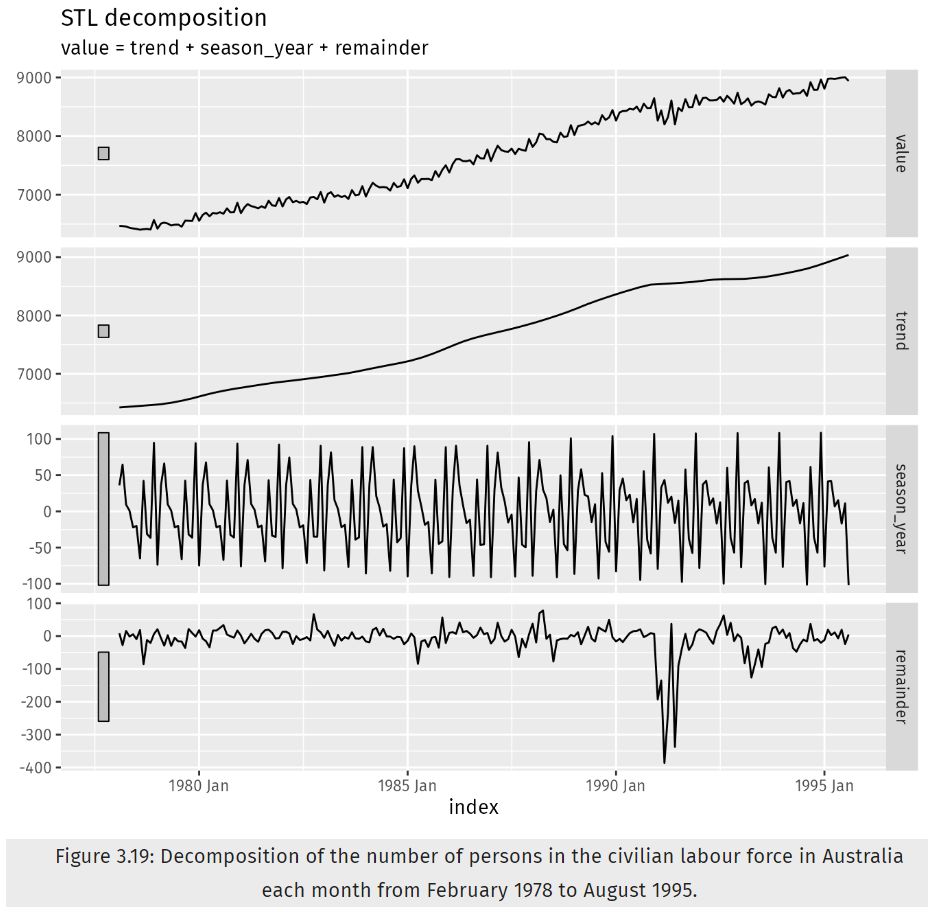

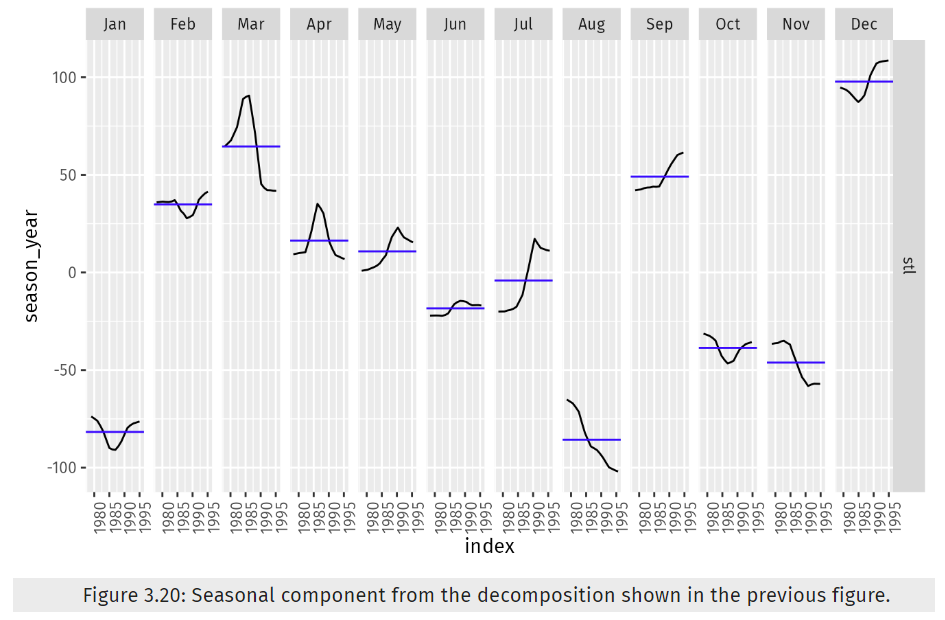

# a.

Write about 3–5 sentences describing the results of the decomposition. Pay particular attention to the scales of the graphs in making your interpretation.

# b.

Is the recession of 1991/1992 visible in the estimated components?

Very much. Its easily observed in the “remainder” plot.